# Notebook

### Web Information Retrieval and Data Mining - Assignment 3

```
Student: Starr, Eliza (1420933)
```

#### Answer 1.1, Baseline (4p)

- Dense network, at least 3 layers, shaped like a pyramid
  - Last layer: 10 nodes, sigmoid.
  - Loss: categorical cross-entropy. Metric: accuracy
- No preprocessing, regularization. Get at least 70% accuracy.
- Explain design decisions. Discuss performance.
  - Does it overfit (large/growing gap between loss and val_loss)?

[output not shown]

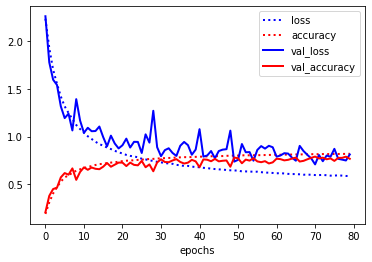

```
Model: "sequential_2"
_________________________________________________________________
Layer (type)                 Output Shape              Param #
=================================================================
reshape_2 (Reshape)          (None, 3072)              0
_________________________________________________________________
dense_12 (Dense)             (None, 320)               983360
_________________________________________________________________
dense_13 (Dense)             (None, 160)               51360
_________________________________________________________________
dense_14 (Dense)             (None, 80)                12880
_________________________________________________________________
dense_15 (Dense)             (None, 40)                3240
_________________________________________________________________
dense_16 (Dense)             (None, 20)                820
_________________________________________________________________
dense_17 (Dense)             (None, 10)                210
=================================================================
Total params: 1,051,870
Trainable params: 1,051,870
Non-trainable params: 0
_________________________________________________________________
None
def build_model_1_1():
    model = models.Sequential()
    model.add(layers.Reshape((3072,), input_shape=(32,32,3)))
    model.add(layers.Dense(output*scale**5, input_dim=(3072,), activation='relu'))
    model.add(layers.Dense(output*scale**4, activation='relu'))
    model.add(layers.Dense(output*scale**3, activation='relu'))
    model.add(layers.Dense(output*scale**2, activation='relu'))
    model.add(layers.Dense(output*scale**1, activation='relu'))
    model.add(layers.Dense(output*scale**0, activation='softmax'))

    model.compile(optimizer='rmsprop',
                  loss='categorical_crossentropy',
                  metrics=['accuracy'])
    return model
```

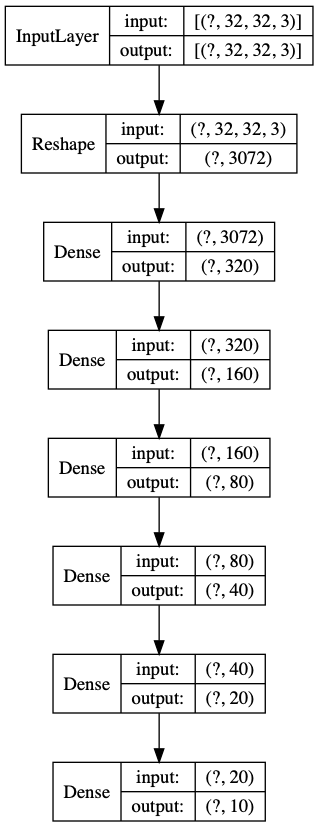

#### Answer 1.2, Preprocess (2p)

- Convert images to greyscale, other preprocessing optional.
  - Input shape should be (32,32,1)
- Explain design decisions. Is it better? Why (not)?
  - Color information is likely not so useful for classification. Greyscale makes the network smaller, less parameters to learn, less likely to overfit.

[output not shown]

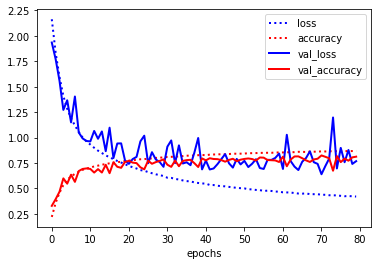

```
Model: "sequential_3"
_________________________________________________________________
Layer (type)                 Output Shape              Param #
=================================================================
reshape_3 (Reshape)          (None, 1024)              0
_________________________________________________________________
dense_18 (Dense)             (None, 320)               328000
_________________________________________________________________
dense_19 (Dense)             (None, 160)               51360
_________________________________________________________________
dense_20 (Dense)             (None, 80)                12880
_________________________________________________________________
dense_21 (Dense)             (None, 40)                3240
_________________________________________________________________
dense_22 (Dense)             (None, 20)                820
_________________________________________________________________
dense_23 (Dense)             (None, 10)                210
=================================================================
Total params: 396,510
Trainable params: 396,510
Non-trainable params: 0
_________________________________________________________________
None
def build_model_1_2():
    model = models.Sequential()
    model.add(layers.Reshape((1024,), input_shape=(32,32, 1)))
    model.add(layers.Dense(output*scale**5, input_dim=(1024,), activation='relu'))
    model.add(layers.Dense(output*scale**4, activation='relu'))
    model.add(layers.Dense(output*scale**3, activation='relu'))
    model.add(layers.Dense(output*scale**2, activation='relu'))
    model.add(layers.Dense(output*scale**1, activation='relu'))
    model.add(layers.Dense(output*scale**0, activation='softmax'))

    model.compile(optimizer='rmsprop',
                  loss='categorical_crossentropy',
                  metrics=['accuracy'])
    return model
```

#### Answer 1.3, Tune (4p)

- Regularize the model. What works best?
  - Should consider batch normalization, dropout, l1/l2 regularization (or Nesterov)
- Tune other hyperparameters (e.g. learning rate, batch size,...) as you see fit.
  - At least consider tuning learning rate, ideally also momentum, decay, other optimizers
- Explain your findings and final design decisions. Discuss the results.
  - Should be better, at least it shouldn't overfit

```
The best accuracy gain (to 83%) was achieved by adding a dropout layer with rate 0.2 before the last dense hidden layer, however this is not a large improvement. Adding other dropout layer combinations or kernel, bias, and activity regularizers of types l1, l2, and l1_l2 did not improve performance.…

Max val score: 83.44%
```

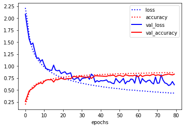

```
def build_model_1_3():
    model = models.Sequential()
    model.add(layers.Reshape((1024,), input_shape=(32,32, 1)))
    model.add(layers.Dense(output*scale**5, input_dim=(1024,), activation='relu',
                           kernel_regularizer=None, bias_regularizer=None, activity_regularizer=None))
    #model.add(layers.Dropout(0.2))
    model.add(layers.Dense(output*scale**4, activation='relu',
                           kernel_regularizer=None, bias_regularizer=None, activity_regularizer=None))
    #model.add(layers.Dropout(0.4))
    model.add(layers.Dense(output*scale**3, activation='relu',
                           kernel_regularizer=None, bias_regularizer=None, activity_regularizer=None))
    #model.add(layers.Dropout(0.3))
    model.add(layers.Dense(output*scale**2, activation='relu',
                           kernel_regularizer=None, bias_regularizer=None, activity_regularizer=None))

    model.add(layers.Dropout(0.2))
    model.add(layers.Dense(output*scale**1,
                           kernel_regularizer=None, bias_regularizer=None, activity_regularizer=None))#l1(0.01)))
    #model.add(layers.BatchNormalization())
    model.add(layers.Activation('relu'))

    model.add(layers.Dense(output*scale**0, activation='softmax',
                           kernel_regularizer=None, bias_regularizer=None, activity_regularizer=None))

    model.compile(optimizer=optimizers.RMSprop(lr=0.0005),
                  loss='categorical_crossentropy',
                  metrics=['accuracy'])
    return model
```

#### Answer 2.1, ConvNet (7p)

- Build a sequential ConvNet, get at least 90% accuracy.
  - Conv2D layers, input shape (32,32,1)
  - Consider using blocks of Conv2D layers with maxpooling in between
  - Use zero-padding in Conv2D layers because the images are small
  - At least one dense hidden layer and dense output layer (sigmoid)
  - Consider adding batch normalization, dropout
  - Consider small dropout rates in beginning, larger dropout rates later in network
  - Consider other optimizers and tuning learning rate, momentum,...
- Explain what you did and why (800 chars). Is it working well?
  - Should be quite elaborate and sensible

[output not shown]

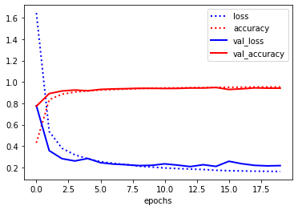

```
Model: "sequential_15"
_________________________________________________________________
Layer (type)                 Output Shape              Param #
=================================================================
conv2d_48 (Conv2D)           (None, 32, 32, 32)        320
_________________________________________________________________
conv2d_49 (Conv2D)           (None, 32, 32, 32)        9248
_________________________________________________________________
max_pooling2d_24 (MaxPooling (None, 16, 16, 32)        0
_________________________________________________________________
dropout_22 (Dropout)         (None, 16, 16, 32)        0
_________________________________________________________________
conv2d_50 (Conv2D)           (None, 16, 16, 64)        18496
_________________________________________________________________
conv2d_51 (Conv2D)           (None, 16, 16, 64)        36928
_________________________________________________________________
max_pooling2d_25 (MaxPooling (None, 8, 8, 64)          0
_________________________________________________________________
dropout_23 (Dropout)         (None, 8, 8, 64)          0
_________________________________________________________________
conv2d_52 (Conv2D)           (None, 8, 8, 128)         73856
_________________________________________________________________
conv2d_53 (Conv2D)           (None, 8, 8, 128)         147584
_________________________________________________________________
max_pooling2d_26 (MaxPooling (None, 4, 4, 128)         0
_________________________________________________________________
dropout_24 (Dropout)         (None, 4, 4, 128)         0
_________________________________________________________________
flatten_6 (Flatten)          (None, 2048)              0
_________________________________________________________________
dense_54 (Dense)             (None, 128)               262272
_________________________________________________________________
dense_55 (Dense)             (None, 10)                1290
=================================================================
Total params: 549,994
Trainable params: 549,994
Non-trainable params: 0
_________________________________________________________________
None
def build_model_2_1():
```

[output cut: 8 more lines]

```
  model.add(layers.MaxPooling2D((2, 2)))
  model.add(layers.Dropout(0.3))

  model.add(layers.Conv2D(128, (3, 3), activation='relu', padding='same'))
  model.add(layers.Conv2D(128, (3, 3), activation='relu', padding='same'))
  model.add(layers.MaxPooling2D((2, 2)))
  model.add(layers.Dropout(0.3))

  model.add(layers.Flatten())
  model.add(layers.Dense(128, activation='relu'))
  model.add(layers.Dense(10, activation='softmax'))
  model.compile(optimizer=optimizers.RMSprop(lr=1e-3),
                loss='categorical_crossentropy',
                metrics=['accuracy'])
  return model
```

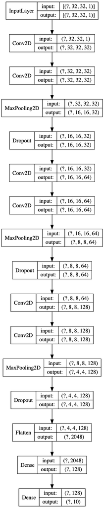

#### Answer 2.2, Data Augmentation (3p)

- Augment the preprocessed training data.
  - Use small variations (small shifts up-down, left-right) of flips becasue the images are small
  - Large shifts and rotations distort the image too much
- Explain what you did and why. Discuss the performance of the model.

```
Using a width and high shift of 0.1, accuracy is 95%. Flipping, shearing, and rotating did not improve the results, and using large augmentations dramatically decreased accuracy. It makes sense that flipping would not help in particular because it is likely very rare that street numbers are flipped.…

Max val score: 94.81%
```

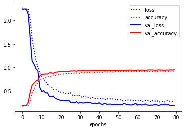

```
train_datagen = ImageDataGenerator(width_shift_range=0.1, height_shift_range=0.1)
```

#### Answer 3.1, Misclassifications (2p)

[output not shown]

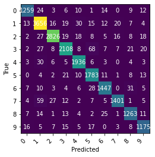

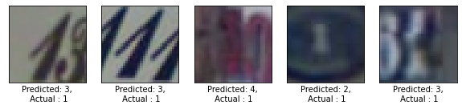

#### Answer 3.2, Activations (4p)

- Retrieve and visualize the activations for one example
- For every filter for different convolutional layers (at different depths in the network).
- Give an explanation. Is your model indeed learning something useful?
  - Should detect edges etc in first layers, higher-order object (e.g. interesting regions) in deeper layers.

[output not shown]

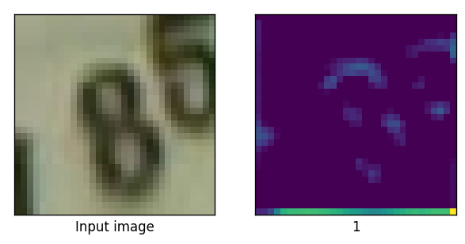

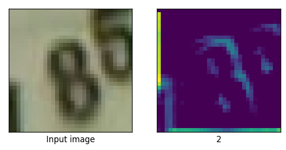

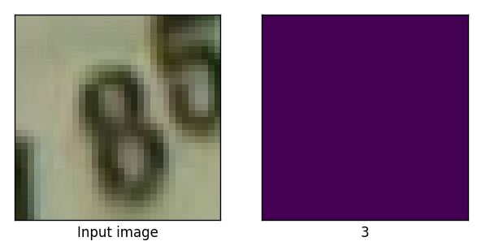

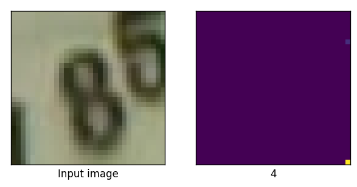

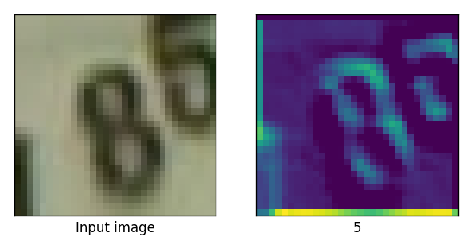

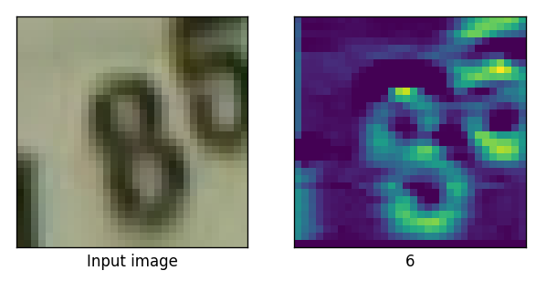

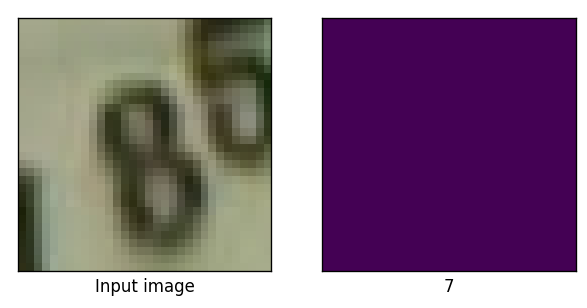

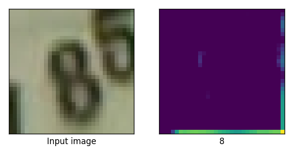

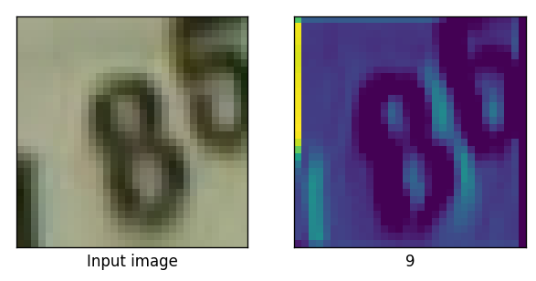

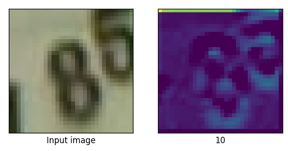

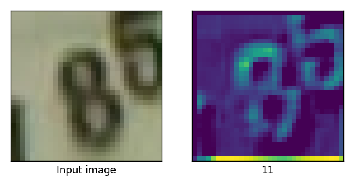

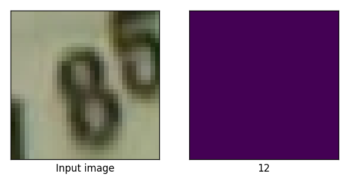

[20 more figures not shown]

#### Answer 3.3, Class activation map (4p)

- Show a class activation map for your last convolutional layer
- Superimpose the activation map over the image, or plot side by side
  - Should make sense, detect interesting regions to classify the number

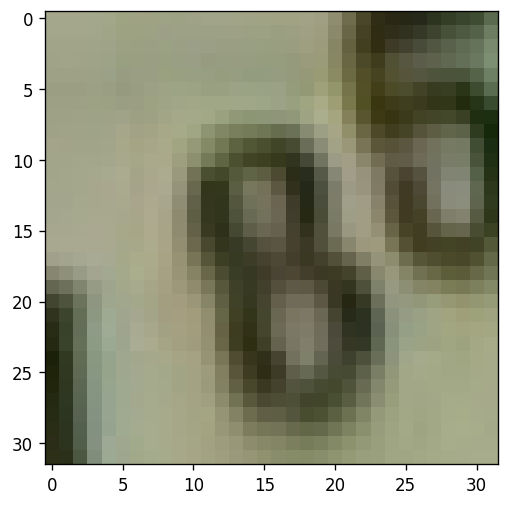

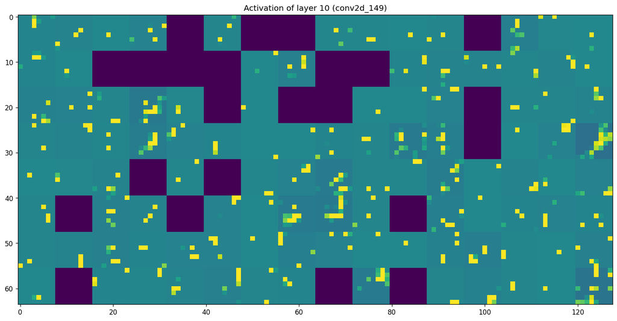

```
def plot_3_3():
    layer_index = 9
    fig, axes = plt.subplots(1, 1,  figsize=(10, 5))
    img_tensor = X_test[0]
    axes.imshow(img_tensor)
    plt.show()

    start = layer_index
    end = layer_index+1
    # Now let's display our feature maps
    for layer_name, layer_activation in zip(layer_names[start:end], activations[start:end]):
        # This is the number of features in the feature map
        n_features = layer_activation.shape[-1]

        # The feature map has shape (1, size, size, n_features)
        size = layer_activation.shape[1]

        # We will tile the activation channels in this matrix
        n_cols = n_features // images_per_row
        display_grid = np.zeros((size * n_cols, images_per_row * size))

        # We'll tile each filter into this big horizontal grid
        for col in range(n_cols):
            for row in range(images_per_row):
                channel_image = layer_activation[0,
                                                 :, :,
                                                 col * images_per_row + row]
                # Post-process the feature to make it visually palatable
                channel_image -= channel_image.mean()
                channel_image /= channel_image.std()
                channel_image *= 64
                channel_image += 128
                channel_image = np.clip(channel_image, 0, 255).astype('uint8')
                display_grid[col * size : (col + 1) * size,
                             row * size : (row + 1) * size] = channel_image

        # Display the grid
        scale = 1. / size
        plt.figure(figsize=(scale * display_grid.shape[1],
                            scale * display_grid.shape[0]))
        plt.title("Activation of layer {} ({})".format(layer_index+1,layer_name))
        plt.grid(False)
        plt.imshow(display_grid, aspect='auto', cmap='viridis')

    plt.show()
```

#### Answer 4.1, Fast feature extraction (5p)

- Import the VGG16 model, pretrained on ImageNet
- Freeze convolutional base, adds a dense layer
- Consider unfreezing the last few convolutional layers and evaluate whether that works better
  - Check if they do. It is very likely to help.
- Discuss the observed performance
  - Should get around 80% accuracy

[output not shown]

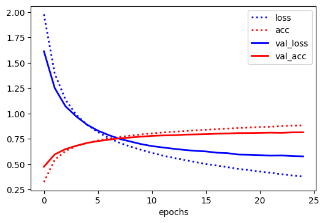

```
Model: "sequential_6"
_________________________________________________________________
Layer (type)                 Output Shape              Param #
=================================================================
vgg16 (Model)                (None, 1, 1, 512)         14714688
_________________________________________________________________
batch_normalization_6 (Batch (None, 1, 1, 512)         2048
_________________________________________________________________
flatten_6 (Flatten)          (None, 512)               0
_________________________________________________________________
dense_14 (Dense)             (None, 128)               65664
_________________________________________________________________
dense_15 (Dense)             (None, 10)                1290
=================================================================
Total params: 14,783,690
Trainable params: 2,427,786
Non-trainable params: 12,355,904
_________________________________________________________________
None
def build_model_4_1():
  # include_top=False does not import the dense layers
  base_model = tf.keras.applications.VGG16(include_top=False, weights='imagenet', input_tensor=None, input_shape=(32,32,3), pooling=None, classes=1000)

  freeze = False

  # By freezing (layer.trainable = False), you prevent the weights in a given layer from being updated during training
  if freeze:
    # freezes the convolutional base
    base_model.trainable = False
  else:
    # unfreezes the last few convolutional layers
    for layer in base_model.layers:
      if layer.name in ['block5_conv1']: #,'block5_conv2','block5_conv3'
          layer.trainable = True
      else:
          layer.trainable = False

  # add a dense layer to the convolutional base
  model = tf.keras.Sequential()
  model.add(base_model)
  model.add(layers.BatchNormalization())
  model.add(layers.Flatten())
  model.add(layers.Dense(128, activation='relu'))
  model.add(keras.layers.Dense(10, activation='softmax'))

  model.compile(loss='categorical_crossentropy',
                optimizer=optimizers.RMSprop(lr=1e-5),
                metrics=['acc'])

  return model
```

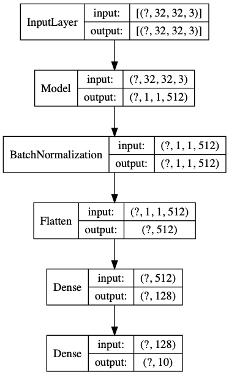

#### Answer 4.2, Embeddings (5p)

- Generate embeddings with the trained convolutional part of model_4_1 (without the dense layer)
- Embed the training and test data and store them to disk
- Build and evaluate a pipeline on the embedded data
  - Check if pipeline makes sense (e.g. use models that can handle many dimensions)
- Describe what you did and what you observed (max 800 chars).
  - Consider different models, preprocessing, tuning, etc.
  - Check performance (see original Submission.html) when in doubt. We did not run all the evaluations because it takes too long, and the output is ill-defined.

[output not shown]

```
Running time: 22.25 seconds
Last modified: May 26, 2020
scikit-learn version: 0.23.1
```